# Public Health and Economic Impact Analysis by Severe Wheater Events

Kiichi Takeuchi

July 23, 2014

# Synopsis

The goal of this analysis is to find impacts from various weather events in the U.S in terms of public health and economic damage. The data set was imported from the U.S. National Oceanic and Atmospheric Administration’s (NOAA) storm database, and I am using R as programming language which the details are described below in multiple steps. This document contains the R code itself, results from analysis and instructions for your reproducibile process.

# Setup

First, the work directory path needs to be setup. If you are using R Studio, you can also set it from Session > Set Working Directory > To Source File Location. Here is my example below.

```r
setwd("~/work/r/class/datasciencecoursera/notes/class5_repdata/assignment2")
```

Below is the list of required R packages for this analysis:

```r
library(data.table)
library(parallel)
library(stringdist)
library(R.utils)
library(xtable)
library(ggplot2)
library(reshape2)
```

Download and extract the Zip file if it was not extracted yet

```r
if (!file.exists("storm.bz2")){
  download.file("https://d396qusza40orc.cloudfront.net/repdata%2Fdata%2FStormData.csv.bz2","storm.bz2",method="curl")
}
if (!file.exists("types.csv")){
  download.file("https://raw.githubusercontent.com/kiichi/datasciencecoursera/master/notes/class5_repdata/assignment2/types.csv","types.csv",method="curl")
}
```

As for references, you can take a look at NOAA’s documentations.

- https://d396qusza40orc.cloudfront.net/repdata%2Fpeer2_doc%2FNCDC%20Storm%20Events-FAQ%20Page.pdf
- https://d396qusza40orc.cloudfront.net/repdata%2Fpeer2_doc%2Fpd01016005curr.pdf

# Data Processing

In this section, data processing steps are presented.

### Loading Data

Next, load the data file. Since I got error with fread function, I’m using read.csv first, then I’m converting into data.table type.

```r
d<-data.table(read.csv("storm.bz2"))
```

### Utility Functions

These functions are created for proprocessing phase. cleanup removes white spaces and force characters to uppercase. unit_num function is for mapping unit of damage in dollar amount (K,M and B). More detailed descriptions are available in following section.

```r
cleanup <- function (x)  {
  toupper(gsub("\\(.+","",gsub("^\\s+|\\s+$", "", x)))
}

unit_num<-function(unit){
  if (is.na(unit)){
    1
  }
  else if (unit == "K"){
    1000
  }
  else if (unit=="M"){
    1000000
  }
  else if (unit=="B"){
    1000000000
  }
  else {
    1
  }
}
```

### Processing Data

Here is my clean up policy below as you see in the code.

- Fix everything to upper case
- Remove all event that contains “summary” in the description
- Remove if all rows that PROPDMG,CROPDMG,INJURIES and FATALITIES columns are zero
- Multiply the property / crop damage depend on the unit. Reference (NATIONAL WEATHER SERVICE INSTRUCTION pdf page 12 second paragraph - “Alphabetical characters used to signify magnitude include K for thousands, M for millions, and B for billions.”

```r
# Remove before 1995
d<-d[as.Date(d$BGN_DATE,"%m/%d/%Y") >= as.Date("1/1/1996","%m/%d/%Y"),]

# Remove if all of PROPDMG,CROPDMG,INJURIES and FATALITIES columns are zero
d<-d[(PROPDMG+CROPDMG+INJURIES+FATALITIES)>0,]

# Upper case and Trim
d[,c("EVTYPE")] <- cleanup(d$EVTYPE)
d[,c("PROPDMGEXP")] <- cleanup(d$PROPDMGEXP)
d[,c("CROPDMGEXP")] <- cleanup(d$CROPDMGEXP)

# Remove summary
d<-d[!(EVTYPE %like% 'SUMMARY'),]
```

```r
uni<-unique(d$EVTYPE)
valid<-cleanup(read.csv("valid.csv")$x)

find_word<-function(original){
  dst<-stringdist(original,valid)
  if (min(dst)>=2){
    original
  }
  else {
    valid[which.min(dst)]
  }
}

trn<-data.table(original=uni)
trn[,c("translated")]<-sapply(uni,find_word)
trn<-trn[original!=translated,]
trn
```

```
##            original       translated
## 1:     RIP CURRENTS      RIP CURRENT
## 2:        HURRICANE       HURRICANE
## 3:     STRONG WINDS      STRONG WIND
## 4: LAKE EFFECT SNOW LAKE-EFFECT SNOW
## 5:       HIGH WINDS        HIGH WIND
```

```r
replace_event<-function(event_type){
  if (any(trn$original==event_type)){
    trn[original==event_type,translated]
  }
  else {
    event_type
  }
}
length(unique(d$EVTYPE))
```

```
## [1] 183
```

```r
d[,c("EVTYPE")]<-sapply(d$EVTYPE,replace_event)
length(unique(d$EVTYPE))
```

```
## [1] 179
```

Finally, we are going to calculate total number of fatalities, injuries, economic damage which are from property damage and crop damage.

```r
d[,c("PHTTL"):=FATALITIES+INJURIES]
d[,c("PROPDMGMULT")] <- sapply(d$PROPDMGEXP,unit_num)
d[,c("CROPDMGMULT")] <- sapply(d$CROPDMGEXP,unit_num)
d[,c("PROPDMG"):=PROPDMG*PROPDMGMULT]
d[,c("CROPDMG"):=CROPDMG*CROPDMGMULT]
d[,c("DMGTTL"):=PROPDMG+CROPDMG]
```

# Results

Results of processed data are presented below.

### Ranking: Public Health

Generate top 10 with following steps: 1) Group by events 2) Sort and extract top 10 3) Display

```r
rk_ph<-d[,list(TOTAL=sum(PHTTL),FATALITIES=sum(FATALITIES),INJURIES=sum(INJURIES)),by=EVTYPE]
rk_ph<-head(rk_ph[order(TOTAL,decreasing=T),],10)
print(xtable(rk_ph,digits=0),type="html",format.args=list(big.mark = ","))
```

|  | EVTYPE | TOTAL | FATALITIES | INJURIES |
| --- | --- | --- | --- | --- |
| 1 | TORNADO | 22,178 | 1,511 | 20,667 |
| 2 | EXCESSIVE HEAT | 8,188 | 1,797 | 6,391 |
| 3 | FLOOD | 7,172 | 414 | 6,758 |
| 4 | LIGHTNING | 4,792 | 651 | 4,141 |
| 5 | TSTM WIND | 3,870 | 241 | 3,629 |
| 6 | FLASH FLOOD | 2,561 | 887 | 1,674 |
| 7 | THUNDERSTORM WIND | 1,530 | 130 | 1,400 |
| 8 | WINTER STORM | 1,483 | 191 | 1,292 |
| 9 | HEAT | 1,459 | 237 | 1,222 |
| 10 | HURRICANE/TYPHOON | 1,339 | 64 | 1,275 |

.

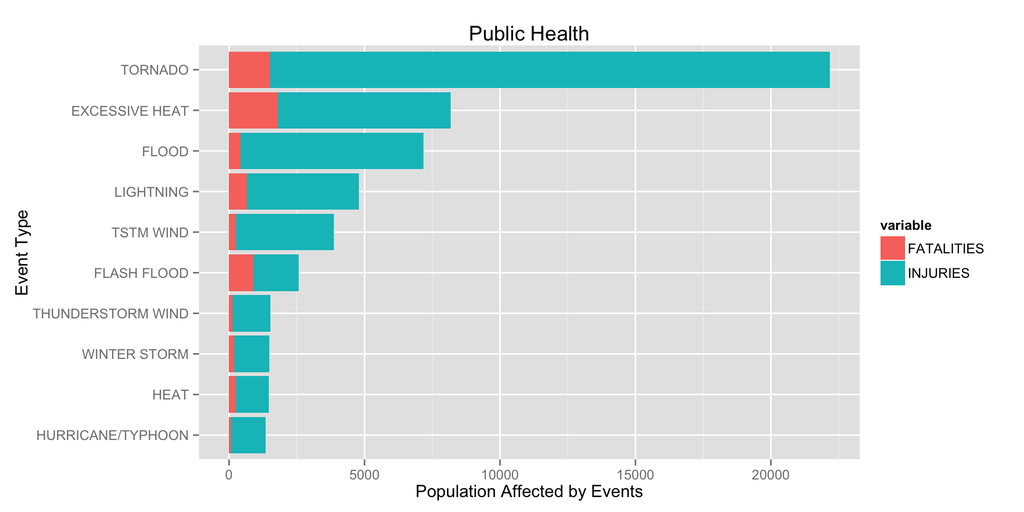

```r
m_ph<-melt(rk_ph[,list(EVTYPE,FATALITIES,INJURIES)], id=c("EVTYPE"))
ggplot(m_ph,aes(factor(EVTYPE,levels=rk_ph[order(rk_ph$TOTAL),]$EVTYPE),fill=variable,y=value)) + geom_bar(stat="identity") + coord_flip() + labs(title="Public Health",x="Event Type",y="Population Affected by Events")
```

### Ranking: Economic Damage

Generate top 10 with following steps: 1) Group by events 2) Sort and extract top 10 3) Display

```r
rk_ed<-d[,list(TOTAL=sum(DMGTTL),PROPDMG=sum(PROPDMG),CROPDMG=sum(CROPDMG)),by=EVTYPE]
rk_ed<-head(rk_ed[order(TOTAL,decreasing=T),],10)
print(xtable(rk_ed,digits=0),type="html",format.args=list(big.mark = ","))
```

|  | EVTYPE | TOTAL | PROPDMG | CROPDMG |
| --- | --- | --- | --- | --- |
| 1 | FLOOD | 148,919,611,950 | 143,944,833,550 | 4,974,778,400 |
| 2 | HURRICANE/TYPHOON | 71,913,712,800 | 69,305,840,000 | 2,607,872,800 |
| 3 | STORM SURGE | 43,193,541,000 | 43,193,536,000 | 5,000 |
| 4 | TORNADO | 24,900,370,720 | 24,616,945,710 | 283,425,010 |
| 5 | HAIL | 17,071,172,870 | 14,595,143,420 | 2,476,029,450 |
| 6 | FLASH FLOOD | 16,557,155,610 | 15,222,253,910 | 1,334,901,700 |
| 7 | HURRICANE | 14,554,229,010 | 11,812,819,010 | 2,741,410,000 |
| 8 | DROUGHT | 14,413,667,000 | 1,046,101,000 | 13,367,566,000 |
| 9 | TROPICAL STORM | 8,320,186,550 | 7,642,475,550 | 677,711,000 |
| 10 | HIGH WIND | 5,881,421,660 | 5,247,860,360 | 633,561,300 |

.

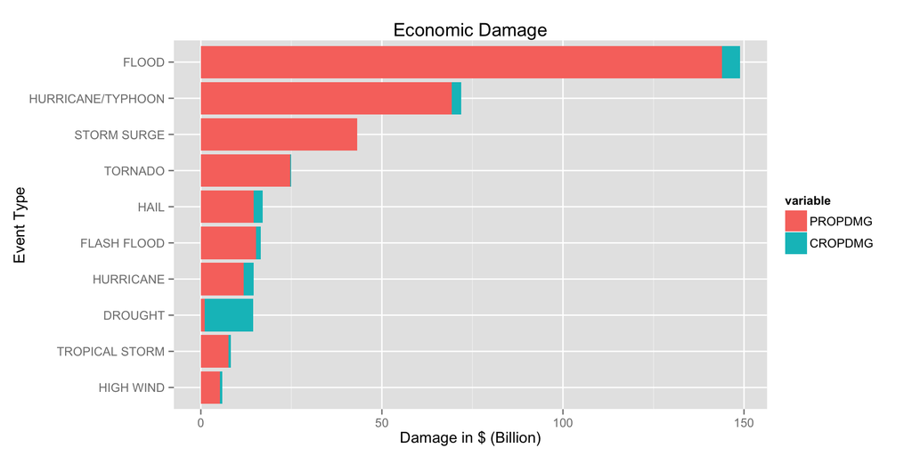

```r
m_ed<-melt(rk_ed[,list(EVTYPE,PROPDMG,CROPDMG)], id=c("EVTYPE"))
ggplot(m_ed,aes(factor(EVTYPE,levels=rk_ed[order(rk_ed$TOTAL),]$EVTYPE),fill=variable,y=value/1000000000.0)) + geom_bar(stat="identity") + coord_flip() + labs(title="Economic Damage",x="Event Type",y="Damage in $ (Billion)")
```

# Miscellaneous

Generate .md document using knitr library as you need

```r
#library(knitr)
#knit2html("PA1_template.Rmd")
```

The published URL is

- http://rpubs.com/kiichi/23256